title: “Analiza danych - Projekt v.0.1” author: “Kamil Kukiełka, Michał Zakielarz, Klaudia Kopeć” date: “2024-06-20” output: pdf_document: default html_document: default —

# Zaczytanie danych i ich przygotowanie

W tym projekcie będziemy korzystać z kilku zestawów danych, tak aby wykazać, że pomimo danych z różnych dziedzin ich predyckja jest w jakimś sposób możliwa

## Zbiór 1

### Zestaw 1

Zawiera on przychodów naszego przedsiębiorstwa.

```
##        Period       Revenue
## 1  01.01.2015 16010072.1195
## 2  01.02.2015 15807587.4498
## 3  01.03.2015 22047146.0236
## 4  01.04.2015 18814583.2943
## 5  01.05.2015 14021479.6117
## 6  01.06.2015 16783928.5221
## 7  01.07.2015 19161892.1949
## 8  01.08.2015 15204984.2967
## 9  01.09.2015 20603939.9751
## 10 01.10.2015 20992874.7801
## 11 01.11.2015 14993369.6576
## 12 01.12.2015 27791807.6398
```

### Zestaw 2

Zawiera ilość sprzedaży w naszej firmie.

```
##        Period Sales_quantity
## 1  01.01.2015          12729
## 2  01.02.2015          11636
## 3  01.03.2015          15922
## 4  01.04.2015          15227
## 5  01.05.2015           8620
## 6  01.06.2015          13160
## 7  01.07.2015          17254
## 8  01.08.2015           8642
## 9  01.09.2015          16144
## 10 01.10.2015          18135
## 11 01.11.2015          10841
## 12 01.12.2015          22113
```

### Zestaw 3

Zawiera średni koszt produkcji w naszej firmie.

```
##        Period  Average_cost
## 1  01.01.2015 1257.76354148
## 2  01.02.2015 1358.50699981
## 3  01.03.2015 1384.69702447
## 4  01.04.2015 1235.60670482
## 5  01.05.2015 1626.62176470
## 6  01.06.2015 1275.37450776
## 7  01.07.2015 1110.57680508
## 8  01.08.2015 1759.42887025
## 9  01.09.2015 1276.25990926
## 10 01.10.2015 1157.58890434
## 11 01.11.2015 1383.02459714
## 12 01.12.2015 1256.80855786
```

### Zestaw 4

Zawiera informację o średniej liczbie pracowników w regionie (rocznie).

```
##        Period Average_annual_payroll_of_regiion
## 1  01.01.2015                          30024676
## 2  01.02.2015                          30024676
## 3  01.03.2015                          30024676
## 4  01.04.2015                          30024676
## 5  01.05.2015                          30024676
## 6  01.06.2015                          30024676
## 7  01.07.2015                          30024676
## 8  01.08.2015                          30024676
## 9  01.09.2015                          30024676
## 10 01.10.2015                          30024676
## 11 01.11.2015                          30024676
## 12 01.12.2015                          30024676
```

## Zbiór 2

Obejmuje średnią dzienną temperaturę w Mumbaiu. Nasz zbiór zawiera więcej danych takich jak wilgoć, prędkość czy kierunek wiartu, jednak my skupimy się tylok na temperaturze.

```
##          Data Temperatura
## 1  01-01-2016        28.4
## 2  02-01-2016        26.8
## 3  03-01-2016        25.5
## 4  04-01-2016        26.4
## 5  05-01-2016        27.1
## 6  06-01-2016        26.9
## 7  07-01-2016        26.1
## 8  08-01-2016        26.6
## 9  09-01-2016        26.3
## 10 10-01-2016        26.0
## 11 11-01-2016        26.1
## 12 12-01-2016        25.1
```

### Zbiór 3

Zawiera on kwartalne dane o długu publicznym USA (podany w milionach USD).

```
##          Data   Dług
## 1  1966-01-01 320999
## 2  1966-04-01 316097
## 3  1966-07-01 324748
## 4  1966-10-01 329319
## 5  1967-01-01 330947
## 6  1967-04-01 322893
## 7  1967-07-01 335896
## 8  1967-10-01 344663
## 9  1968-01-01 349473
## 10 1968-04-01 345369
## 11 1968-07-01 354743
## 12 1968-10-01 358029
```

# Zamiana na szereg czasowy

Teraz kiedy mamy już nasze dane musimy je zamienić na szeregi czasowe.

```r
z1ts1 <- ts(z1df1$Revenue,start=c(2015,1),frequency = 12)
z1ts2 <- ts(z1df2$Sales_quantity,start=c(2015,1),frequency = 12)
z1ts3 <- ts(z1df3$Average_cost,start=c(2015,1),frequency = 12)
z1ts4 <- ts(z1df4$Average_annual_payroll_of_regiion,start=c(2015,1),frequency = 12)
z2ts1 <- ts(z2df1$Temperatura, start = c(2016,1,1), frequency = 365)
z3ts1 <- ts(z3df1$Dług, start = c(1966,1), frequency = 4)
```

Mając nasze dane w tej formie możemy narysować wykresy, aby zobaczyć jak wyglądają.

Zbiór 1 zestaw 1

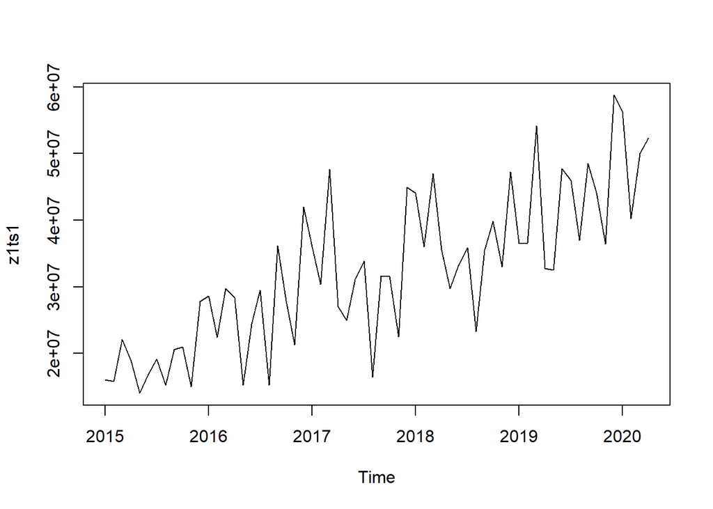

```r
plot(z1ts1)
```

Zbiór 1 zestaw 2

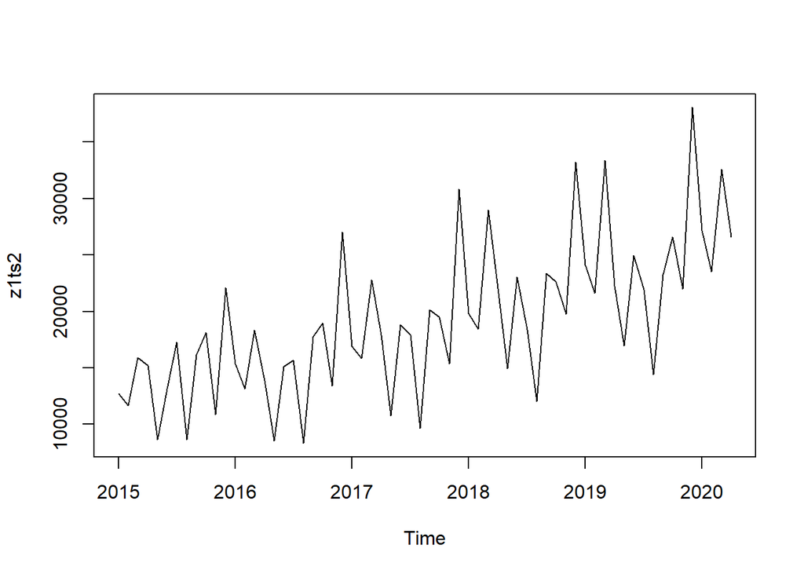

```r
plot(z1ts2)
```

Zbiór 1 zestaw 3

```r
plot(z1ts3)
```

[output not shown]

Zbiór 1 zestaw 4

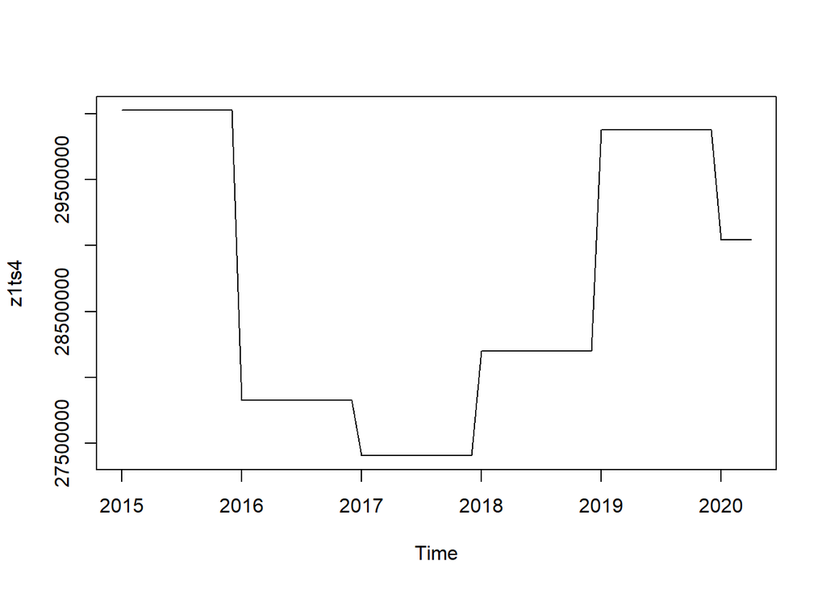

```r
plot(z1ts4)
```

Zbiór 2

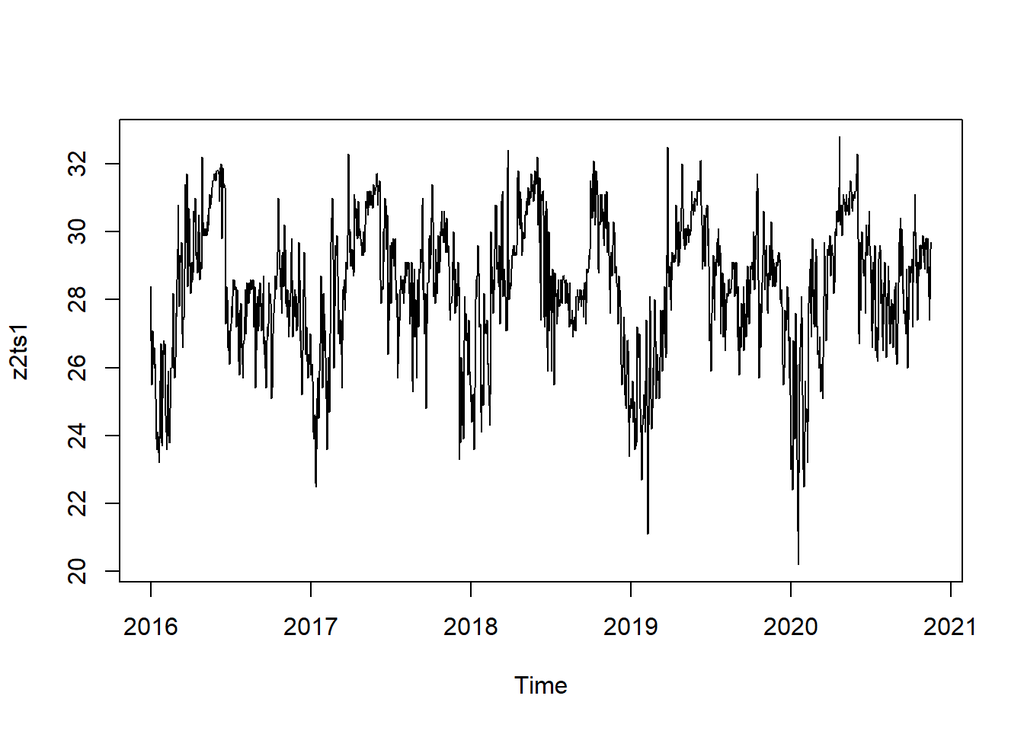

```r
plot(z2ts1)
```

Zbiór 3

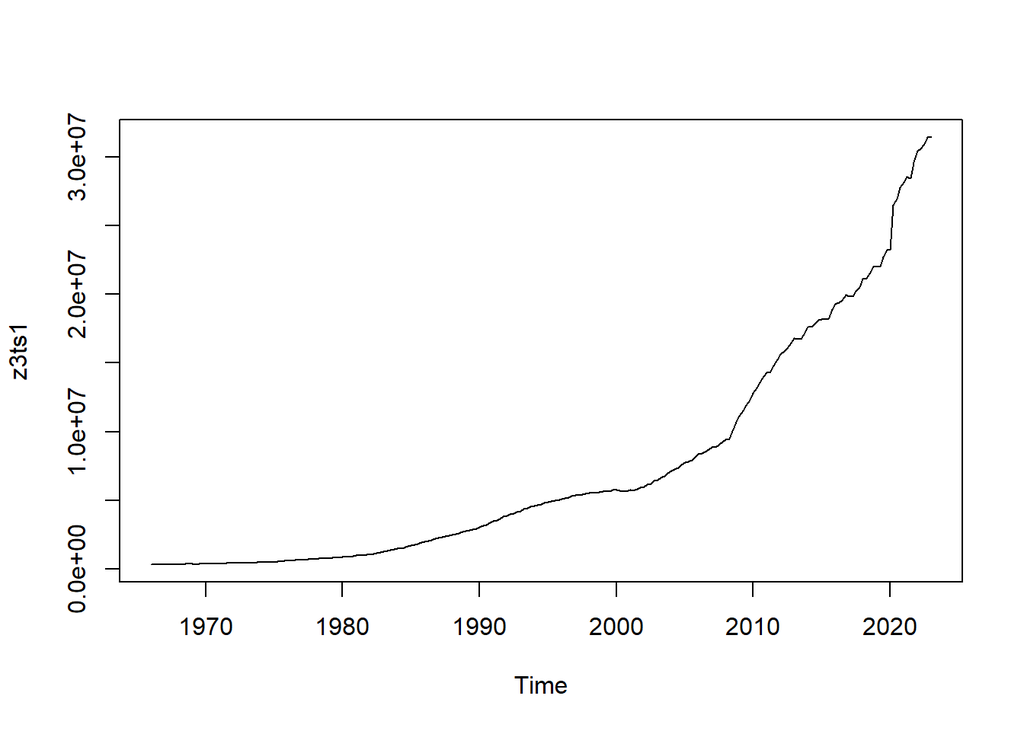

```r
plot(z3ts1)
```

# Przeprowadzenie testów

## Autokorelacja

Przeprowadzimy teraz test na autokrelacje, za pomocą korelogramów oraz testu Durbina-Watsona

## Zbiór 1

### Dla zestawu 1

Autokorelacja przychodów przedsiębiorstwa.

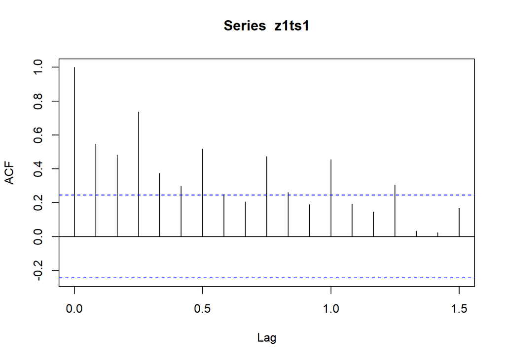

```r
acf(z1ts1)
```

Autokorelacja cząstkowa przychodów przedsiębiorstwa.

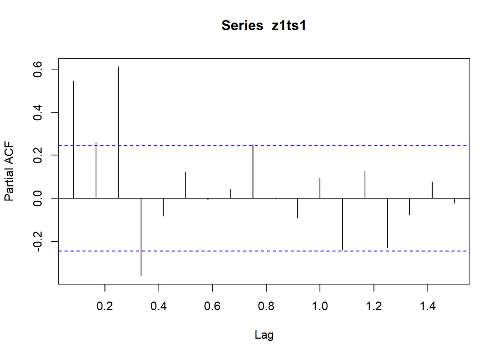

```r
pacf(z1ts1)
```

Test Durbina-Watsona

```r
df=data.frame(time=1:length(z1ts1),z1ts1)
z1lm1<-lm(z1ts1~time,data = df)
dwtest(z1lm1,order.by = NULL)
```

```
##
##  Durbin-Watson test
##
## data:  z1lm1
## DW = 2.201376609, p-value = 0.751966677
## alternative hypothesis: true autocorrelation is greater than 0
```

### Dla zestawu 2

Autokorelacja ilości sprzedarzy w firmie.

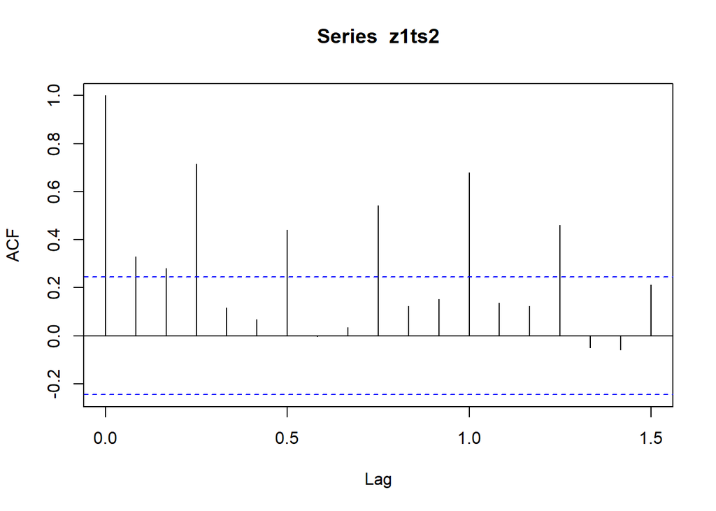

```r
acf(z1ts2)
```

Autokorelacja cząstkowa ilości sprzedarzy w firmie.

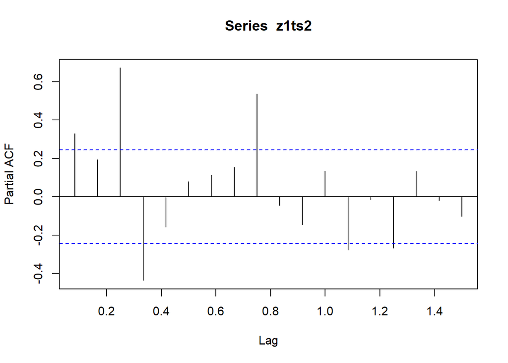

```r
pacf(z1ts2)
```

Test Durbina-Watsona

```r
df=data.frame(time=1:length(z1ts2),z1ts2)
z1lm2<-lm(z1ts2~time,data = df)
dwtest(z1lm2)
```

```
##
##  Durbin-Watson test
##
## data:  z1lm2
## DW = 2.301678967, p-value = 0.861847786
## alternative hypothesis: true autocorrelation is greater than 0
```

### Dla zestawu 3

Autokorelacja średniego kosztu produkcji w firmie.

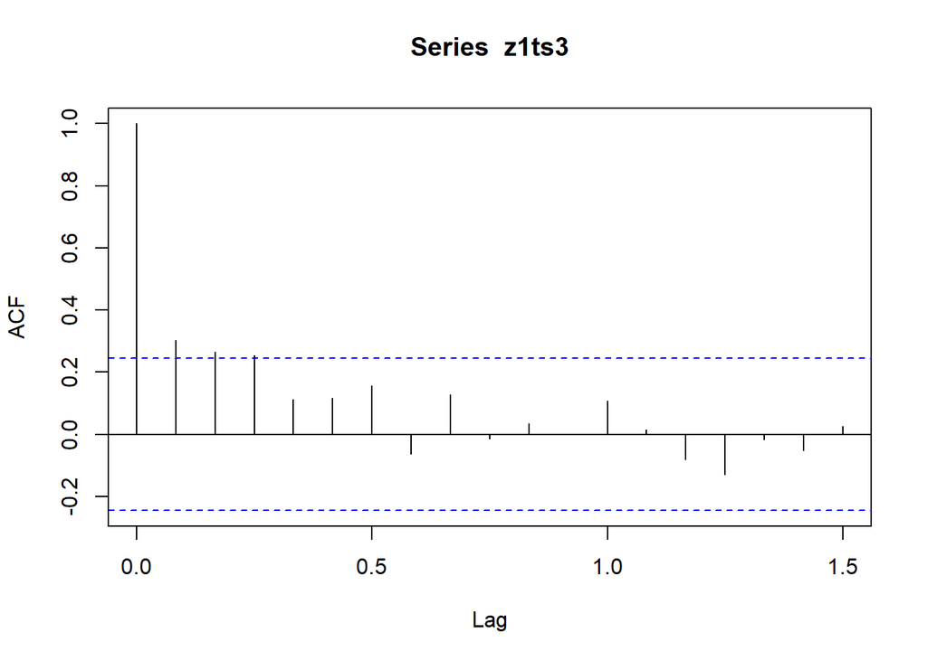

```r
acf(z1ts3)
```

Autokorelacja średniego kosztu produkcji w firmie.

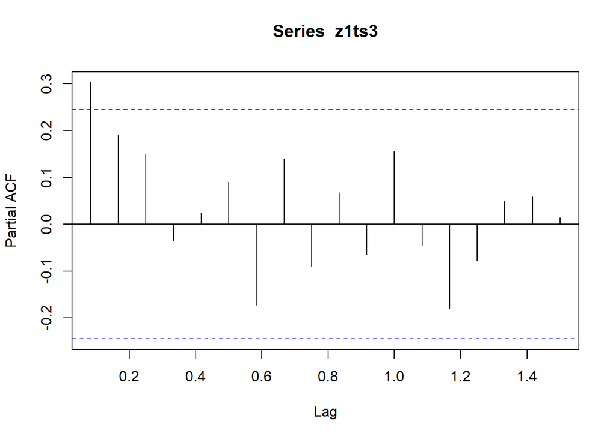

```r
pacf(z1ts3)
```

Test Durbina-Watsona

```r
df=data.frame(time=1:length(z1ts3),z1ts3)
z1lm3<-lm(z1ts3~time,data = df)
dwtest(z1lm3)
```

```
##
##  Durbin-Watson test
##
## data:  z1lm3
## DW = 1.59917854, p-value = 0.0392624752
## alternative hypothesis: true autocorrelation is greater than 0
```

Z powyżej wykonanych testów wynika, że mamy doczynienia z minimalną pozytywną autokorelacją i jest ona istotna statystycznie.

### Dla zestawu 4

Autokorelacja informacji o średniej liczbie pracowników w regionie.

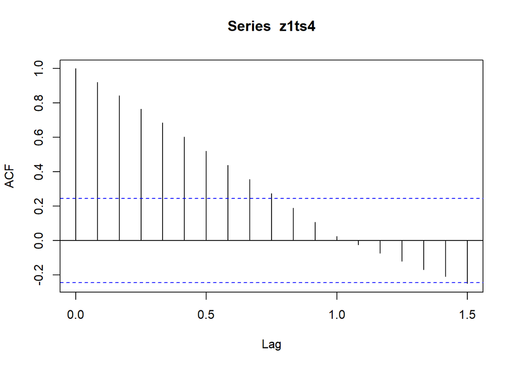

```r
acf(z1ts4)
```

Autokorelacja informacji o średniej liczbie pracowników w regionie.

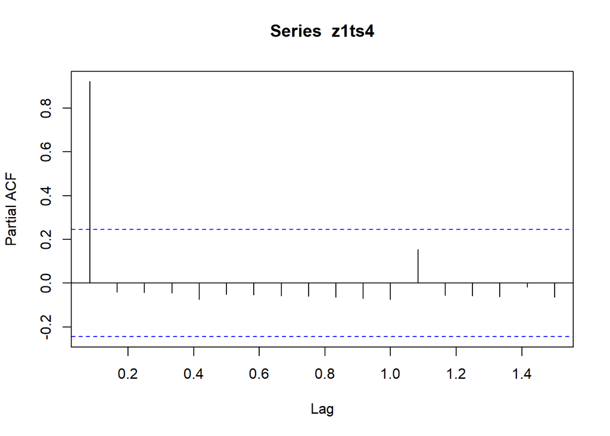

```r
pacf(z1ts4)
```

Test Durbina-Watsona

```r
df=data.frame(time=1:length(z1ts4),z1ts4)
z1lm4<-lm(z1ts4~time,data = df)
dwtest(z1lm4)
```

```
##
##  Durbin-Watson test
##
## data:  z1lm4
## DW = 0.1302507942, p-value < 2.220446e-16
## alternative hypothesis: true autocorrelation is greater than 0
```

Z powyżej wykonanych testów wynika, że mamy doczynienia z silną pozytywną autokorelacją, która jest istotna statystycznie

## Dla zbioru 2

Autokorelacja średniej dziennej temperatury w Mumbaiu.

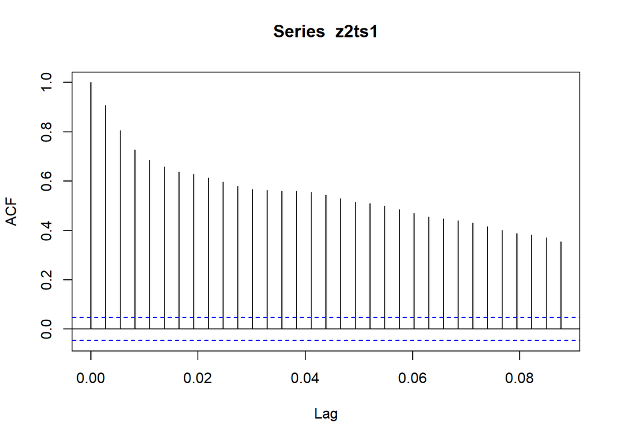

```r
acf(z2ts1)
```

Autokorelacja średniej dziennej temperatury w Mumbaiu.

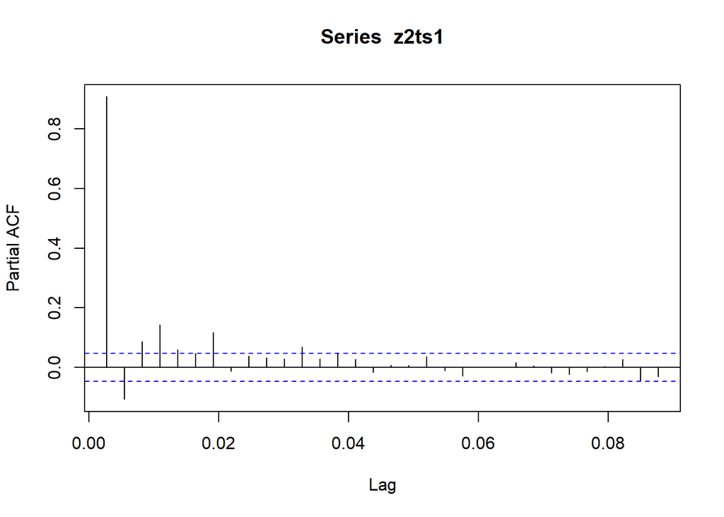

```r
pacf(z2ts1)
```

Test Durbina-Watsona

```r
df=data.frame(time=1:length(z2ts1),z2ts1)
z2lm1<-lm(z2ts1~time,data = df)
dwtest(z2lm1)
```

```
##
##  Durbin-Watson test
##
## data:  z2lm1
## DW = 0.1842113922, p-value < 2.220446e-16
## alternative hypothesis: true autocorrelation is greater than 0
```

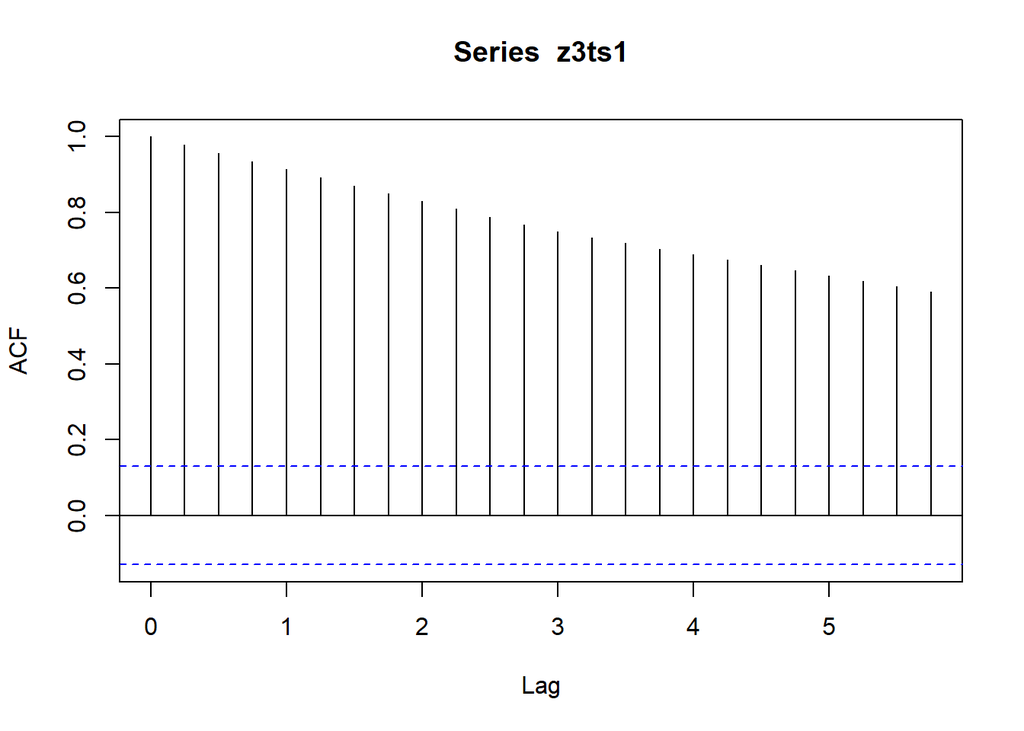

```r
acf(z3ts1)
```

Autokorelacja kwartalnych danych o długu publicznym USA.

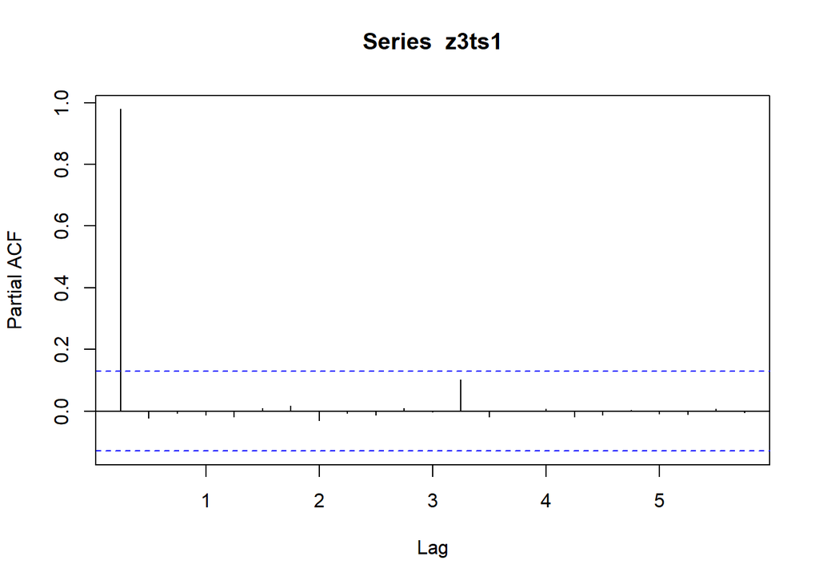

```r
pacf(z3ts1)
```

Test Durbina-Watsona

```r
df=data.frame(time=1:length(z3ts1),z3ts1)
z3lm1<-lm(z3ts1~time,data = df)
dwtest(z3lm1)
```

```
##
##  Durbin-Watson test
##
## data:  z3lm1
## DW = 0.005619120769, p-value < 2.220446e-16
## alternative hypothesis: true autocorrelation is greater than 0
```

Z powyżej wykonanych testów wynika, że mamy doczynienia z silną pozywyną autokorelacją, która jest istotna statystycznie

# Test na heteroskedastyczność

Aby określić heteroskedastyczność szeregu, należy najpierw stworzyć model liniowy z naszych szeregów czasowych, a następnie przeprowadzić test Breuscha-Pagana.

### Zbiór 1

## Dla zestawu 1

Heteroskedastyczność przychodów przedsiębiorstwa.

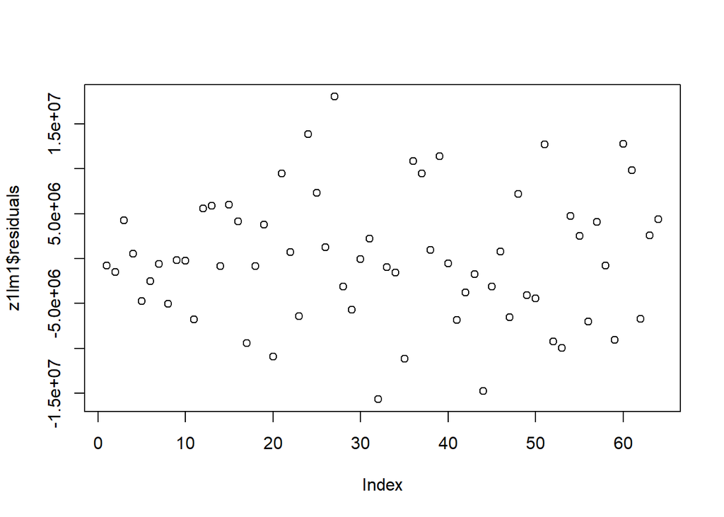

```r
plot(z1lm1$residuals)
```

```r
bptest(z1lm1)
```

```
##
##  studentized Breusch-Pagan test
##
## data:  z1lm1
## BP = 1.953845408, df = 1, p-value = 0.162173073
```

## Dla zestawu 2

Heteroskedastyczność ilości sprzedarzy w firmie.

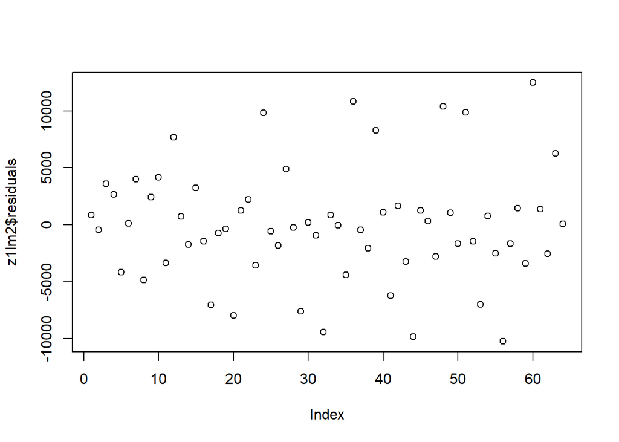

```r
plot(z1lm2$residuals)
```

```r
 bptest(z1lm2)
```

```
##
##  studentized Breusch-Pagan test
##
## data:  z1lm2
## BP = 2.573564, df = 1, p-value = 0.10866267
```

Wykonując powyższy test wynika, że wartość p jest większa niż 0,05, co prowadzi do nieodrzucenia hipotezy zerowej. W konsekwencji, *nie posiadamy wystarczających dowodów na występowanie heteroskedastyczności.*

## Dla zestawu 3

Heteroskedastyczność średniego kosztu produkcji w firmie.

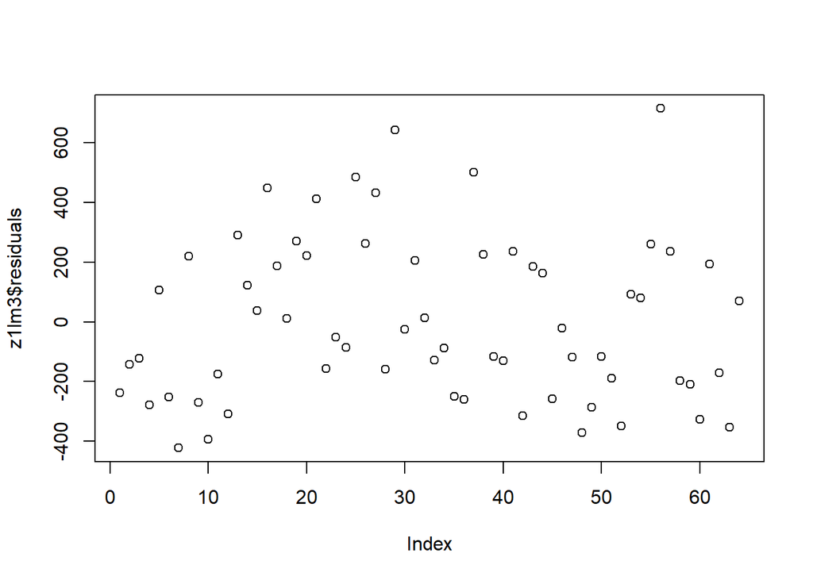

```r
df=data.frame(time=1:length(z1ts3),z1ts3)
z1lm3<-lm(z1ts3~time,data = df)
plot(z1lm3$residuals)
```

```r
 bptest(z1lm3)
```

```
##
##  studentized Breusch-Pagan test
##
## data:  z1lm3
## BP = 0.04862771469, df = 1, p-value = 0.825468592
```

## Dla zestawu 4

Heteroskedastyczność informacji o średniej liczbie pracowników w regionie.

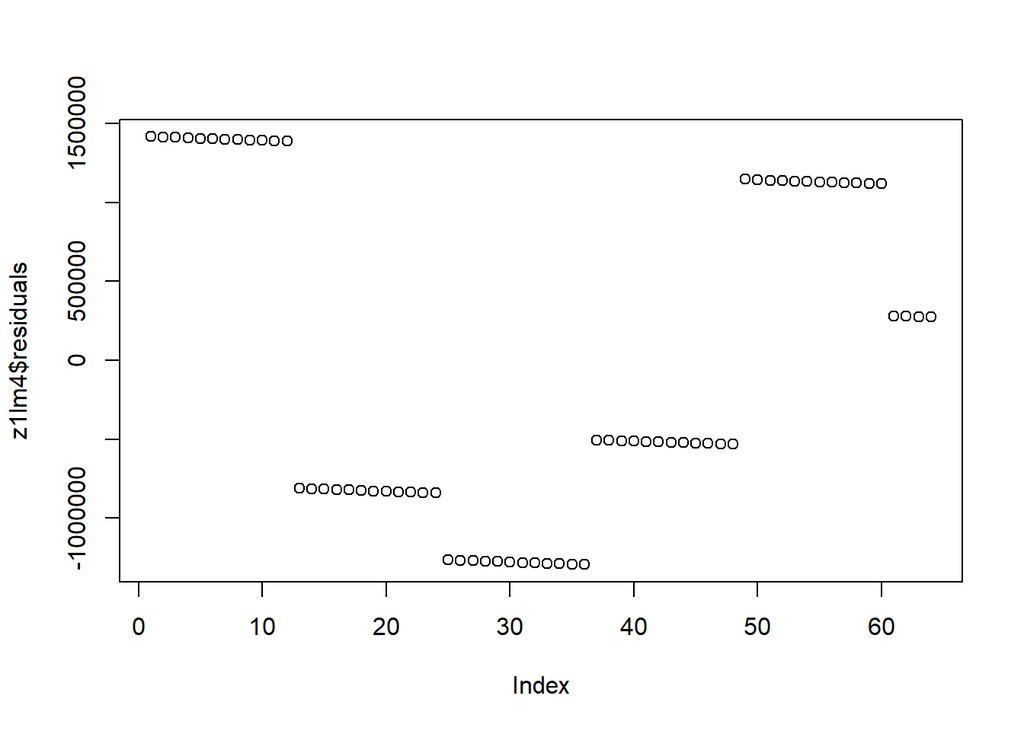

```r
df=data.frame(time=1:length(z1ts4),z1ts4)
z1lm4<-lm(z1ts4~time,data = df)
plot(z1lm4$residuals)
```

```r
 bptest(z1lm4)
```

```
##
##  studentized Breusch-Pagan test
##
## data:  z1lm4
## BP = 16.05643948, df = 1, p-value = 6.14821832e-05
```

### Zbioru 2

Heteroskedastyczność średniej dziennej temperatury w Mumbaiu.

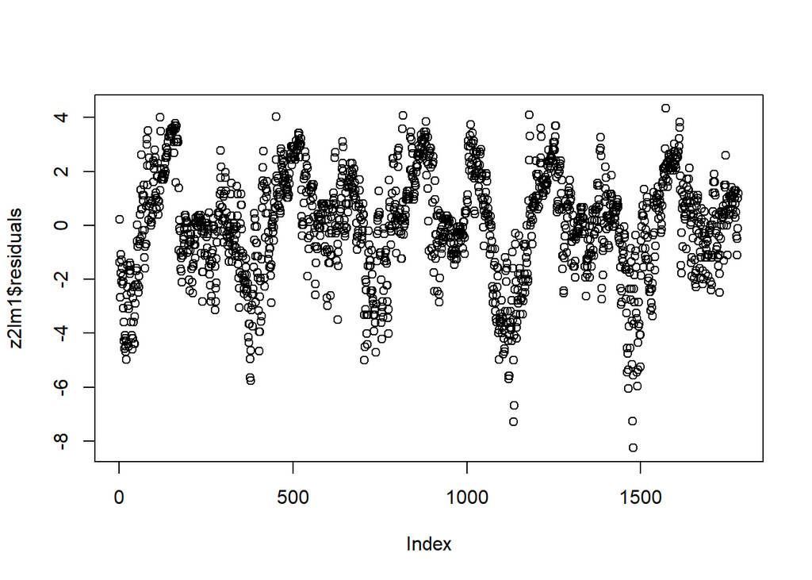

```r
df=data.frame(time=1:length(z2ts1),z2ts1)
z2lm1<-lm(z2ts1~time,data = df)
plot(z2lm1$residuals)
```

```r
 bptest(z2lm1)
```

```
##
##  studentized Breusch-Pagan test
##
## data:  z2lm1
## BP = 3.859278805, df = 1, p-value = 0.0494715892
```

### Zbioru 3

Heteroskedastyczność kwartalnych danych o długu publicznym USA.

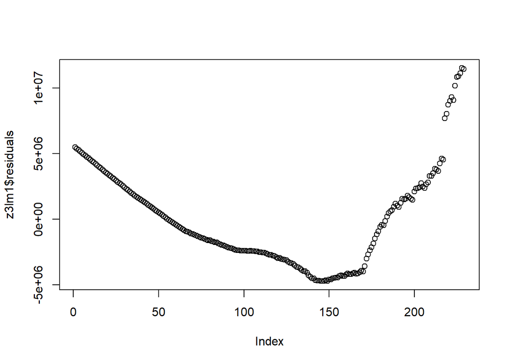

```r
df=data.frame(time=1:length(z3ts1),z3ts1)
z3lm1<-lm(z3ts1~time,data = df)
plot(z3lm1$residuals)
```

```r
 bptest(z3lm1)
```

```
##
##  studentized Breusch-Pagan test
##
## data:  z3lm1
## BP = 30.18331407, df = 1, p-value = 3.9307678e-08
```

# Test na stacjonarność szergu

## Dla zbioru 1 seria 1

```r
urca::ur.kpss(z1ts1) %>% summary() #niestacjonarny
```

```
##
## #######################
## # KPSS Unit Root Test #
## #######################
##
## Test is of type: mu with 3 lags.
##
## Value of test-statistic is: 1.4597
##
## Critical value for a significance level of:
##                 10pct  5pct 2.5pct  1pct
## critical values 0.347 0.463  0.574 0.739
```

```r
diff(z1ts1) %>% urca::ur.kpss() %>% summary() # stacjonarny
```

```
##
## #######################
## # KPSS Unit Root Test #
## #######################
##
## Test is of type: mu with 3 lags.
##
## Value of test-statistic is: 0.0268
##
## Critical value for a significance level of:
##                 10pct  5pct 2.5pct  1pct
## critical values 0.347 0.463  0.574 0.739
```

```r
urca::ur.kpss(z1ts2) %>% summary() #niestacjonarny
```

```
##
## #######################
## # KPSS Unit Root Test #
## #######################
##
## Test is of type: mu with 3 lags.
##
## Value of test-statistic is: 1.3016
##
## Critical value for a significance level of:
##                 10pct  5pct 2.5pct  1pct
## critical values 0.347 0.463  0.574 0.739
```

```r
diff(z1ts2) %>% urca::ur.kpss() %>% summary() # stacjonarny
```

```
##
## #######################
## # KPSS Unit Root Test #
## #######################
##
## Test is of type: mu with 3 lags.
##
## Value of test-statistic is: 0.0226
##
## Critical value for a significance level of:
##                 10pct  5pct 2.5pct  1pct
## critical values 0.347 0.463  0.574 0.739
```

## Dla zbioru 1 serii 3

```r
urca::ur.kpss(z1ts3) %>% summary() #niestacjonarny
```

```
##
## #######################
## # KPSS Unit Root Test #
## #######################
##
## Test is of type: mu with 3 lags.
##
## Value of test-statistic is: 0.5867
##
## Critical value for a significance level of:
##                 10pct  5pct 2.5pct  1pct
## critical values 0.347 0.463  0.574 0.739
```

```r
diff(z1ts3) %>% urca::ur.kpss() %>% summary() # stacjonarny
```

```
##
## #######################
## # KPSS Unit Root Test #
## #######################
##
## Test is of type: mu with 3 lags.
##
## Value of test-statistic is: 0.0388
##
## Critical value for a significance level of:
##                 10pct  5pct 2.5pct  1pct
## critical values 0.347 0.463  0.574 0.739
```

##Dla zbioru 1 serii 4

```r
urca::ur.kpss(z1ts4) %>% summary() #stacjonarny
```

```
##
## #######################
## # KPSS Unit Root Test #
## #######################
##
## Test is of type: mu with 3 lags.
##
## Value of test-statistic is: 0.3626
##
## Critical value for a significance level of:
##                 10pct  5pct 2.5pct  1pct
## critical values 0.347 0.463  0.574 0.739
```

##Dla zbioru 2 serii 1

```r
urca::ur.kpss(z2ts1) %>% summary() #stacjonarny
```

```
##
## #######################
## # KPSS Unit Root Test #
## #######################
##
## Test is of type: mu with 8 lags.
##
## Value of test-statistic is: 0.1644
##
## Critical value for a significance level of:
##                 10pct  5pct 2.5pct  1pct
## critical values 0.347 0.463  0.574 0.739
```

##Dla zbioru 3 serii 1

```r
urca::ur.kpss(z3ts1) %>% summary() #niestacjonarny
```

```
##
## #######################
## # KPSS Unit Root Test #
## #######################
##
## Test is of type: mu with 4 lags.
##
## Value of test-statistic is: 3.8553
##
## Critical value for a significance level of:
##                 10pct  5pct 2.5pct  1pct
## critical values 0.347 0.463  0.574 0.739
```

```r
diff(z3ts1,lag=1) %>% urca::ur.kpss() %>% summary() # niestacjonarny
```

```
##
## #######################
## # KPSS Unit Root Test #
## #######################
##
## Test is of type: mu with 4 lags.
##
## Value of test-statistic is: 2.3749
##
## Critical value for a significance level of:
##                 10pct  5pct 2.5pct  1pct
## critical values 0.347 0.463  0.574 0.739
```

```r
residuals(z3lm1) %>% urca::ur.kpss() %>% summary() # niestacjonarny
```

```
##
## #######################
## # KPSS Unit Root Test #
## #######################
##
## Test is of type: mu with 4 lags.
##
## Value of test-statistic is: 0.9918
##
## Critical value for a significance level of:
##                 10pct  5pct 2.5pct  1pct
## critical values 0.347 0.463  0.574 0.739
```

```r
log(z3ts1) %>% urca::ur.kpss() %>% summary()# niestacjonarny
```

```
##
## #######################
## # KPSS Unit Root Test #
## #######################
##
## Test is of type: mu with 4 lags.
##
## Value of test-statistic is: 4.6172
##
## Critical value for a significance level of:
##                 10pct  5pct 2.5pct  1pct
## critical values 0.347 0.463  0.574 0.739
```

W szeregach z1ts1, z1ts2, z1ts3 mieliśmy doczynienia z szeregami niestacjonarnymi, które udało nam się sprowadzić do postaci stacjonarnej, szergi z1ts4, z2ts1 są stacjonarne, natomiast z3ts1 okazał się być niestacjonarny i nie można go sprowadzić do postaci stacjonarnej w prosty sposób.

# Tworzenie modelu

## Zbiór 1 seria 1

Bazując na naszych wcześniejszych danych musimy teraz dobrać odpowiednie parametry naszego modelu. Jako iż będziemy korzystać z modelu Arima potrzebujemy wartośći parametrów p,d,q.

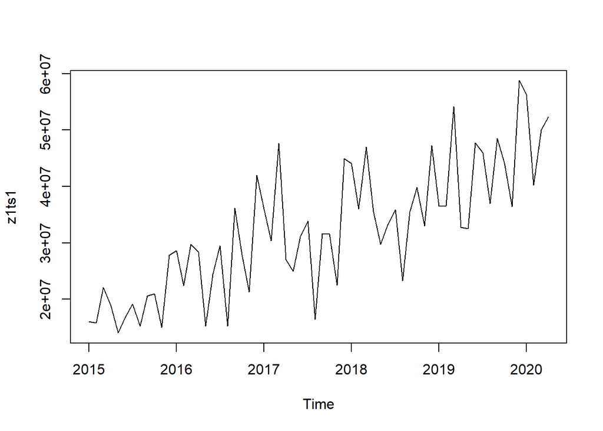

```r
plot(z1ts1) #roboczo
```

Aby wyznaczyć parametr p patrzymy na nasze korelogramy.

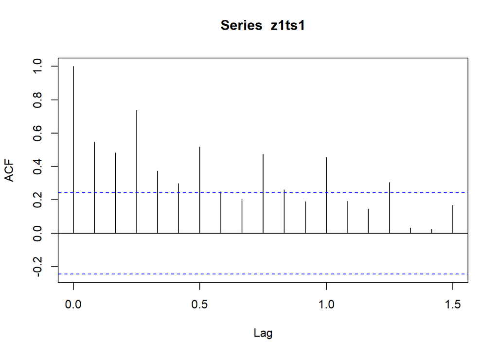

```r
acf(z1ts1)
```

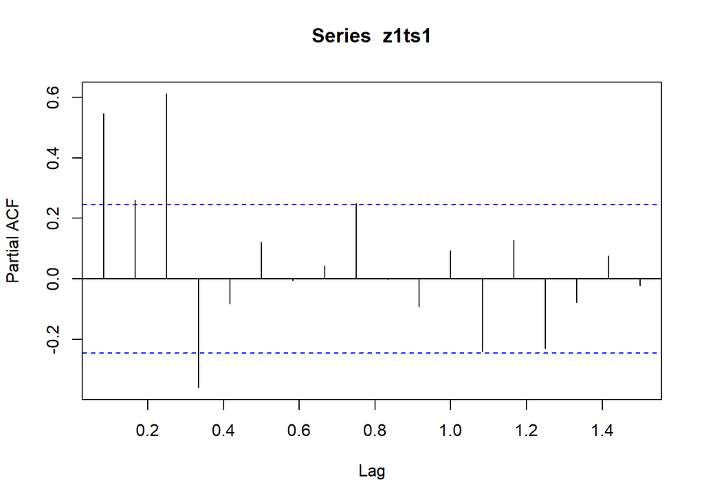

```r
pacf(z1ts1)
```

Możemy na nich zauważyć, że nie występuje jednoznaczna autokorelacja. W takim wypadku możemy nasze dane zróżnicować

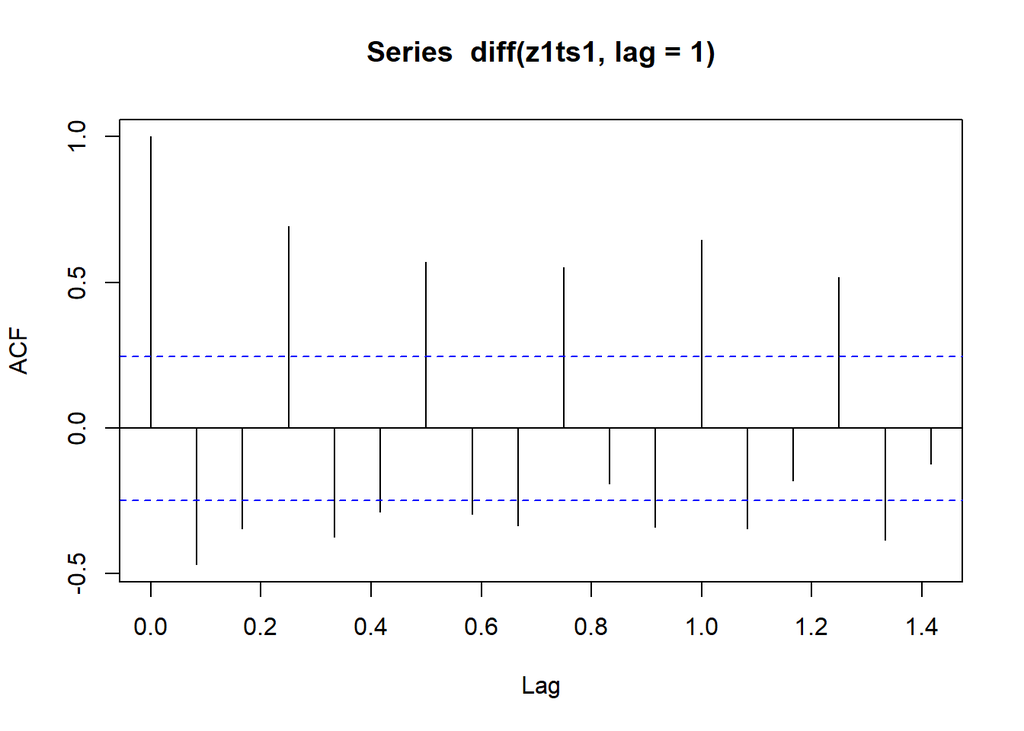

```r
acf(diff(z1ts1,lag = 1))
```

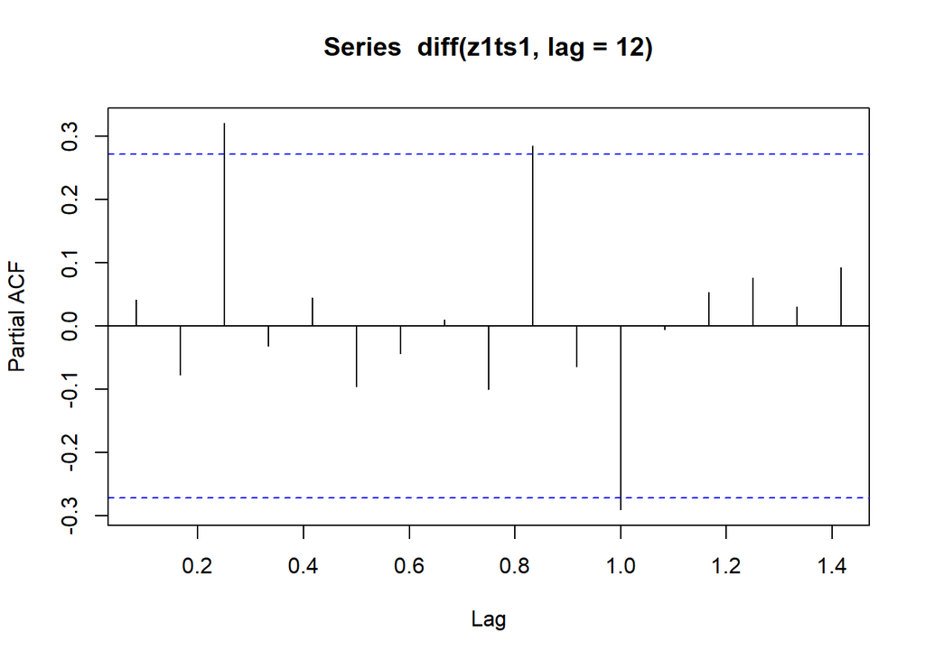

```r
pacf(diff(z1ts1,lag = 12))
```

Na podstawie powyższych wykresów mając orientację jakie wartości możemy wrzucić do modelu testujemy kilka opcji

```r
print("Wersja 1")
```

```
## [1] "Wersja 1"
```

```r
Arima(y=z1ts1, order = c(3,1,3),lambda = NULL)
```

```
## Series: z1ts1
## ARIMA(3,1,3)
##
## Coefficients:
##                ar1           ar2          ar3          ma1         ma2
##       -0.760086155  -0.766437955  0.232583729  0.233656795  0.35649738
## s.e.   0.262887081   0.260511953  0.260991861  0.229629835  0.21278346
##                ma3
##       -0.693226700
## s.e.   0.229245461
##
## sigma^2 = 33530603079204:  log likelihood = -1071.24
## AIC=2156.49   AICc=2158.52   BIC=2171.49
```

```r
print("Wersja 2")
```

```
## [1] "Wersja 2"
```

```r
Arima(y=z1ts1,lambda = NULL,seasonal = c(3,1,3))
```

```
## Series: z1ts1
## ARIMA(0,0,0)(3,1,3)[12]
##
## Coefficients:
##              sar1         sar2          sar3          sma1          sma2
##       0.492440620  0.964345776  -0.469791583  -0.834397448  -0.775037701
## s.e.  1.586720318  0.699113912   1.461010870   3.107421562   1.914644422
##              sma3
##       0.784376344
## s.e.  2.542298555
##
## sigma^2 = 35684037515948:  log likelihood = -897.43
## AIC=1808.86   AICc=1811.41   BIC=1822.52
```

```r
print("Wersja 3")
```

```
## [1] "Wersja 3"
```

```r
Arima(y=z1ts1, order = c(0,1,0),lambda = NULL)
```

```
## Series: z1ts1
## ARIMA(0,1,0)
##
## sigma^2 = 1.12400577e+14:  log likelihood = -1108.52
## AIC=2219.03   AICc=2219.1   BIC=2221.17
```

```r
print("Wersja 4")
```

```
## [1] "Wersja 4"
```

```r
test <- Arima(y=z1ts1,lambda = NULL,seasonal = c(1,1,1))
print("Wersja 5")
```

```
## [1] "Wersja 5"
```

```r
Arima(y=z1ts1, order = c(0,1,0),lambda = "auto")
```

```
## Series: z1ts1
## ARIMA(0,1,0)
## Box Cox transformation: lambda= 0.706549181705
##
## sigma^2 = 4379015456:  log likelihood = -788.7
## AIC=1579.39   AICc=1579.46   BIC=1581.54
```

```r
print("Wersja 6")
```

```
## [1] "Wersja 6"
```

```r
z1tst1_best_model <- Arima(y=z1ts1,lambda = "auto",seasonal = c(0,1,0))
z1tst1_best_model
```

```
## Series: z1ts1
## ARIMA(0,0,0)(0,1,0)[12]
## Box Cox transformation: lambda= 0.706549181705
##
## sigma^2 = 2904276762:  log likelihood = -640.31
## AIC=1282.62   AICc=1282.7   BIC=1284.57
```

Z pośród stworznych modeli wybraliśmy najlepszy, teraz spróbujemy stowrzyć model AutoArima i spróbujemy go porównać z obecnie najlepszym

```r
auto.arima(z1ts1,d=1,max.p = 5,max.q =5,max.d = 5,seasonal = TRUE)
```

```
## Series: z1ts1
## ARIMA(2,1,0)(1,1,0)[12]
##
## Coefficients:
##                ar1           ar2          sar1
##       -0.670729490  -0.533708478  -0.540121180
## s.e.   0.130560826   0.134873128   0.135814968
##
## sigma^2 = 28227103851676:  log likelihood = -863.08
## AIC=1734.16   AICc=1735.03   BIC=1741.88
```

Podsumowując nasz wcześniejszy model jest najlepszy.

Teraz tworząc następne modele postępujemy analogicznie jak powyżej

## Zbiór 1 seria 2

Szacujemy nasze parametry p i q

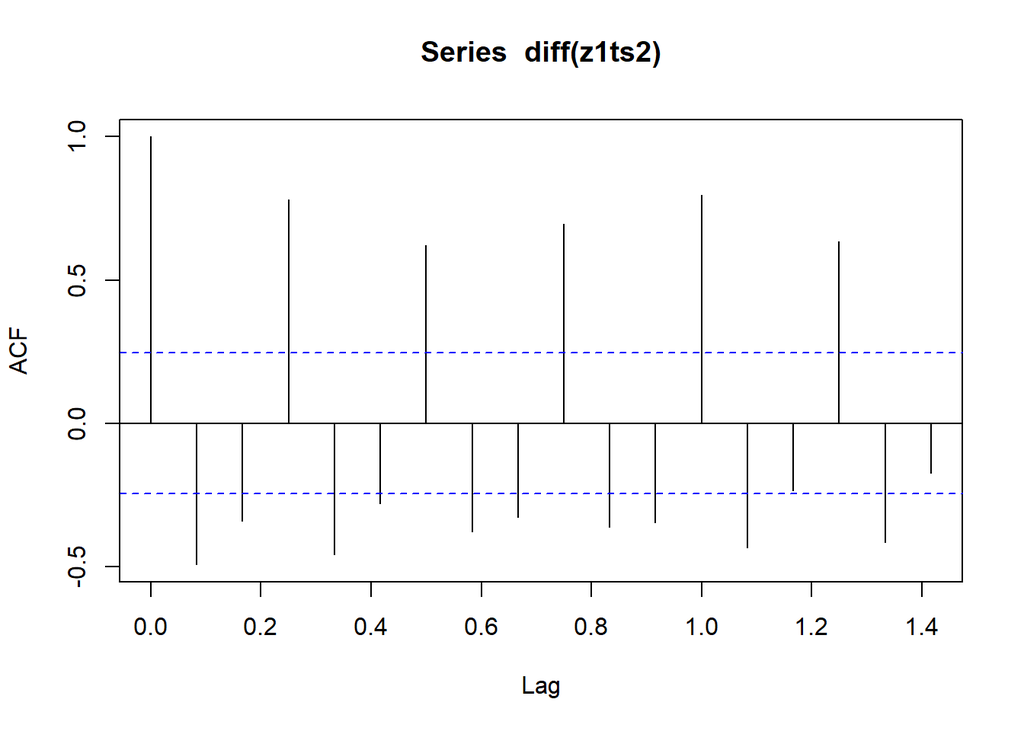

```r
acf(diff(z1ts2)) # 0 lub 1
```

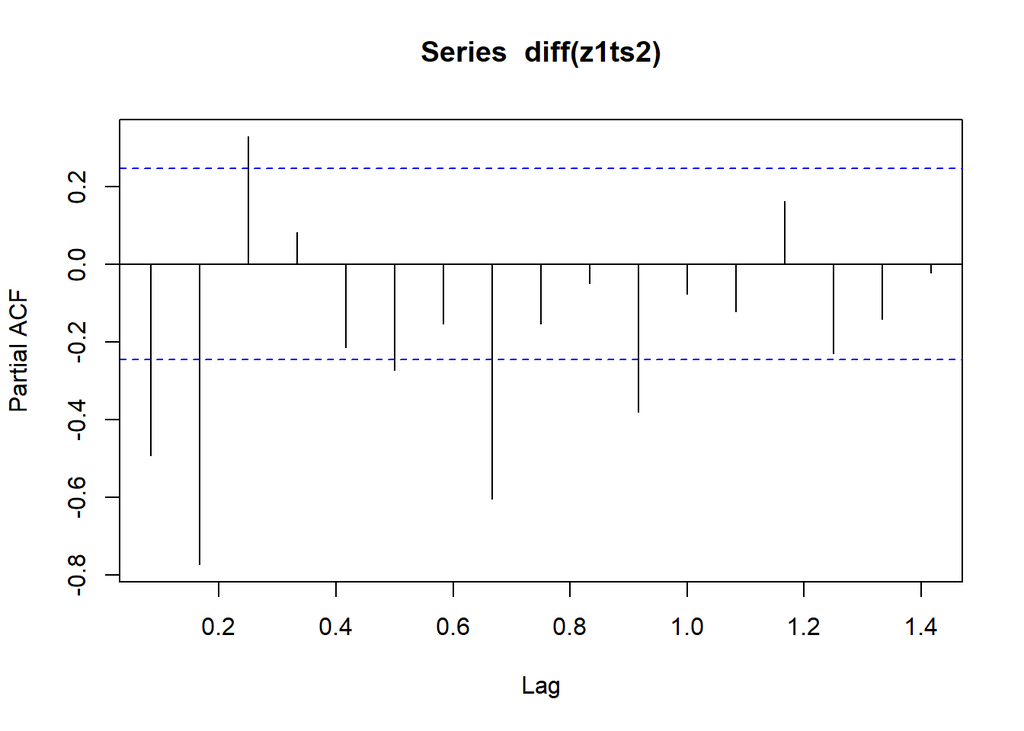

```r
pacf(diff(z1ts2)) # bardziej 0
```

Tworzymy nasze modele i ja porównujemy

```r
print("Wersja 1")
```

```
## [1] "Wersja 1"
```

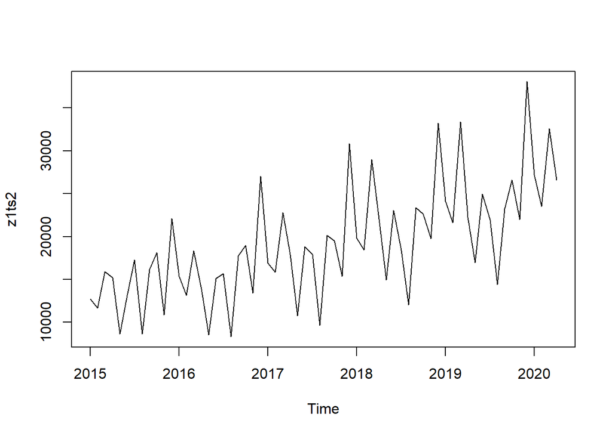

```r
plot(z1ts2)
```

```r
Arima(y=z1ts2, order = c(0,1,0),lambda = NULL)
```

```
## Series: z1ts2
## ARIMA(0,1,0)
##
## sigma^2 = 56800927.1:  log likelihood = -651.83
## AIC=1305.66   AICc=1305.72   BIC=1307.8
```

```r
print("Wersja 2")
```

```
## [1] "Wersja 2"
```

```r
Arima(y=z1ts2,lambda = NULL,seasonal = c(0,1,1))
```

```
## Series: z1ts2
## ARIMA(0,0,0)(0,1,1)[12]
##
## Coefficients:
##              sma1
##       0.999760336
## s.e.  0.432905161
##
## sigma^2 = 3857387.83:  log likelihood = -477.6
## AIC=959.2   AICc=959.44   BIC=963.1
```

```r
print("Wersja 3")
```

```
## [1] "Wersja 3"
```

```r
Arima(y=z1ts2, seasonal = c(0,1,1),lambda = 'auto')
```

```
## Series: z1ts2
## ARIMA(0,0,0)(0,1,1)[12]
## Box Cox transformation: lambda= 0.24348758416
##
## Coefficients:
##              sma1
##       0.999988124
## s.e.  0.411690982
##
## sigma^2 = 1.26346924:  log likelihood = -89.37
## AIC=182.75   AICc=182.99   BIC=186.65
```

```r
print("Wersja 4")
```

```
## [1] "Wersja 4"
```

```r
z1ts2_best_model<-Arima(y=z1ts2, seasonal = c(0,1,1),lambda = 'auto')
```